# Plantilla Modelado y evaluación de los datos

**Objetivo:** Construir, entrenar e interpretar modelos de aprendizaje automático utilizando los datos preparados, y evaluar su desempeño para seleccionar la mejor alternativa.

> Para cada subsección encontrarás una celda *Markdown* con instrucciones y una celda de *Python* para tu código.

```python
# Importes generales
import numpy as np
import pandas as pd
import matplotlib.pyplot as plt
import seaborn as sns

# Selección y validación de modelos
from sklearn.model_selection import train_test_split, cross_val_score, StratifiedKFold, GridSearchCV, RandomizedSearchCV

# Métricas estrictamente para clasificación
from sklearn.metrics import accuracy_score, precision_score, recall_score, f1_score, roc_auc_score, confusion_matrix

from sklearn.preprocessing import StandardScaler


# Modelos de clasificación
from sklearn.linear_model import LogisticRegression
from sklearn.tree import DecisionTreeClassifier       # Árboles de decisión
from sklearn.ensemble import RandomForestClassifier
from sklearn.svm import SVC                           # Máquinas de Vectores de Soporte
from sklearn.neural_network import MLPClassifier      # Redes neuronales (Perceptrón Multicapa)
```

## 1. Selección del tipo de modelo

- Determinar si el problema es de clasificación, regresión o agrupamiento.
- Elegir los algoritmos adecuados según el tipo de problema y la naturaleza de los datos. Ejemplos:
  - Clasificación: Regresión logística, Árboles de decisión, Random Forest, SVM, Redes neuronales.
  - Regresión: Regresión lineal, Random Forest Regressor, XGBoost, Redes neuronales.
  - Agrupamiento: K-Means, DBSCAN, Hierarchical Clustering

Después de un proceso de análisis en grupo, hemos determinado que nuestro reto del Spaceship Titan es un problema de clasificación binaria supervisada porque la variable objetivo **transported**, es categórica booleana y busca determinar a que categoría pertenece cada pasajero. Consideramos que es un reto de supervisión porque contamos con el conjunto de datos de entrenamiento que contiene ya la variable respuesta conocida para entrenar el modelo.

Por último, es binaria dado a que lo que nuestros modelos buscarán predecir es ver si es verdadero o falso la variable objetivo.

## 2. Separación de los conjuntos de datos

- Confirma la **separación train/test** (y opcionalmente *validation*).
- Asegura **reproducibilidad** (semilla aleatoria).

```python
# Escribe tu código aquí

# Se cargan los datos
df = pd.read_csv("data_for_modeling.csv")
df_limpio = df.copy()

# Separar variables predictoras (X) y objetivo (y)
X = df_limpio.drop('Transported', axis=1)
y = df_limpio['Transported'].astype(int)

# Al definir random_state=42, garantizamos que el corte de datos sea siempre igual.
# stratify=y asegura que la proporción de clases se mantenga en Train y Test.
X_train, X_test, y_train, y_test = train_test_split(
    X, y,
    test_size=0.2,
    random_state=42,
    stratify=y
)



# Se confirma separación de separación entre Train y Test
print("--- Confirmación de la Separación Train/Test ---")
print(f"Total de datos disponibles: {len(X)} registros")
print(f"Conjunto de Entrenamiento (Train): {len(X_train)} registros ({len(X_train)/len(X):.1%})")
print(f"Conjunto de Prueba (Test): {len(X_test)} registros ({len(X_test)/len(X):.1%})")

print("\nEquilibrio de clases ('Transported') en Entrenamiento:")
print(y_train.value_counts(normalize=True).round(4))

print("\nEquilibrio de clases ('Transported') en Prueba:")
print(y_test.value_counts(normalize=True).round(4))
```

```
--- Confirmación de la Separación Train/Test ---
Total de datos disponibles: 8693 registros
Conjunto de Entrenamiento (Train): 6954 registros (80.0%)
Conjunto de Prueba (Test): 1739 registros (20.0%)

Equilibrio de clases ('Transported') en Entrenamiento:
Transported
1    0.5036
0    0.4964
Name: proportion, dtype: float64

Equilibrio de clases ('Transported') en Prueba:
Transported
1    0.5037
0    0.4963
Name: proportion, dtype: float64
```

## 3. Entrenamiento del modelo

- Ajustar el modelo a los datos de entrenamiento mediante el método fit().
- Controlar el proceso con métricas de entrenamiento (por ejemplo, accuracy, pérdida, etc.).
- Guardar los parámetros y configuraciones del modelo

```python
# Escribe tu código aquí

import joblib

# 1. Inicializar el modelo con semilla aleatoria
modelo_rf = RandomForestClassifier(random_state=42)

# 2. Ajustar el modelo a los datos de entrenamiento mediante fit()
print("Entrenando el modelo Random Forest...")
modelo_rf.fit(X_train, y_train)

# 3. Controlar el proceso con métricas del entrenamiento
y_pred_train_rf = modelo_rf.predict(X_train)
accuracy_train_rf = accuracy_score(y_train, y_pred_train_rf)

print("\n--- Métricas de Entrenamiento ---")
print(f"Exactitud (Accuracy) en Train: {accuracy_train_rf:.4f}")


# 4. Guardar los parámetros y configuraciones del modelo
print("\n--- Parámetros del Modelo ---")
parametros = modelo_rf.get_params()
for param, valor in parametros.items():
    print(f"{param}: {valor}")

# Guardar el modelo entrenado en un archivo para su uso posterior
archivo_modelo = 'modelo_random_forest_base.pkl'
joblib.dump(modelo_rf, archivo_modelo)
print(f"\n¡Modelo y configuraciones guardados exitosamente en '{archivo_modelo}'!")
```

```
Entrenando el modelo Random Forest...

--- Métricas de Entrenamiento ---
Exactitud (Accuracy) en Train: 0.9994

--- Parámetros del Modelo ---
bootstrap: True
ccp_alpha: 0.0
class_weight: None
criterion: gini
max_depth: None
max_features: sqrt
max_leaf_nodes: None
max_samples: None
min_impurity_decrease: 0.0
min_samples_leaf: 1
min_samples_split: 2
min_weight_fraction_leaf: 0.0
monotonic_cst: None
n_estimators: 100
n_jobs: None
oob_score: False
random_state: 42
verbose: 0
warm_start: False

¡Modelo y configuraciones guardados exitosamente en 'modelo_random_forest_base.pkl'!
```

## 4. Validación y ajuste de hiperparámetros

- Aplicar técnicas de validación cruzada (cross-validation) para medir la robustez del modelo.
- Utilizar métodos de optimización de hiperparámetros:
  - Grid Search
  - Random Search
  - Bayesian Optimization o frameworks como Optuna.
- Ajustar los parámetros que maximizan el desempeño del modelo.

```python
# Escribe tu código aquí

from sklearn.model_selection import cross_val_score, GridSearchCV
import joblib

# --- 1. Validación Cruzada del modelo base ---
print("Aplicando Validación Cruzada al Random Forest base...")
# n_jobs=-1 para optimización
puntuaciones_cv_rf = cross_val_score(modelo_rf, X_train, y_train, cv=5, scoring='accuracy', n_jobs=-1)

print(f"Exactitud en cada partición: {puntuaciones_cv_rf}")
print(f"Exactitud Media (Base): {puntuaciones_cv_rf.mean():.4f}")
print(f"Desviación Estándar: {puntuaciones_cv_rf.std():.4f}")

# --- 2. Ajuste de Hiperparámetros con Grid Search ---
print("\nIniciando Grid Search para optimización de hiperparámetros...")

# Definimos el grid específico para Random Forest
parametros_grid_rf = {
    'n_estimators': [100, 200],
    'max_depth': [4, 6, 8, 10],
    'min_samples_split': [10, 20, 30],
    'min_samples_leaf': [5, 10, 20]
}

# Configurar el GridSearchCV
grid_search_rf = GridSearchCV(
    estimator=RandomForestClassifier(random_state=42),
    param_grid=parametros_grid_rf,
    cv=5,
    scoring='accuracy',
    n_jobs=-1,
    verbose=1 # Mostrará el progreso (ej. "Fitting 5 folds for each of 36 candidates")
)

# Entrenar el Grid Search
grid_search_rf.fit(X_train, y_train)

# Guardar el modelo optimizado
mejor_modelo_rf = grid_search_rf.best_estimator_
joblib.dump(mejor_modelo_rf, 'mejor_modelo_random_forest.pkl')

print("\n--- Resultados de la Optimización ---")
print(f"Mejores Parámetros Encontrados: {grid_search_rf.best_params_}")
print(f"Mejor Exactitud durante Validación Cruzada: {grid_search_rf.best_score_:.4f}")
```

```
Aplicando Validación Cruzada al Random Forest base...
Exactitud en cada partición: [0.79511143 0.79798706 0.79367362 0.78432782 0.80935252]
Exactitud Media (Base): 0.7961
Desviación Estándar: 0.0081

Iniciando Grid Search para optimización de hiperparámetros...
Fitting 5 folds for each of 72 candidates, totalling 360 fits

--- Resultados de la Optimización ---
Mejores Parámetros Encontrados: {'max_depth': 10, 'min_samples_leaf': 5, 'min_samples_split': 10, 'n_estimators': 100}
Mejor Exactitud durante Validación Cruzada: 0.8013
```

## 5. Evaluación del modelo

- Evalúa en **X_test, y_test** con métricas adecuadas:
  - Clasificación: *accuracy*, *precision*, *recall*, *F1*, **ROC-AUC**, matriz de confusión.
  - Regresión: **MAE**, **RMSE**, **R²**.
  - Agrupamiento: **Silhouette Score**, **Davies–Bouldin**.
- Analiza **sesgo y varianza** (under/overfitting).

```
--- Evaluación en Conjunto de Prueba (Random Forest Optimizado) ---
Accuracy:  0.7970
Precision: 0.7955
Recall:    0.8037
F1-Score:  0.7995
ROC-AUC:   0.8964

--- Análisis de Sesgo y Varianza ---
Rendimiento en Entrenamiento (Train): 0.8422
Rendimiento en Prueba (Test):         0.7970
Diferencia (Train - Test):            0.0452

Diagnóstico: BALANCE ADECUADO. El modelo generaliza de forma excelente.
```

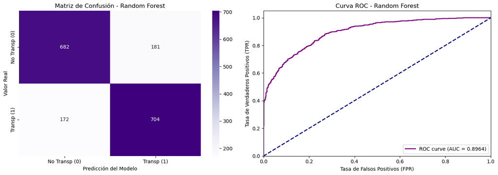

```python
# Escribe tu código aquí

from sklearn.metrics import accuracy_score, precision_score, recall_score, f1_score, roc_auc_score, confusion_matrix, roc_curve
import matplotlib.pyplot as plt
import seaborn as sns

# --- 1. Generar predicciones y probabilidades para Train y Test ---
y_pred_train_rf = mejor_modelo_rf.predict(X_train)
y_pred_test_rf = mejor_modelo_rf.predict(X_test)

# predict_proba para la Curva ROC (probabilidad de ser clase 1)
y_prob_train_rf = mejor_modelo_rf.predict_proba(X_train)[:, 1]
y_prob_test_rf = mejor_modelo_rf.predict_proba(X_test)[:, 1]

# --- 2. Cálculo de métricas principales en Test ---
acc_rf = accuracy_score(y_test, y_pred_test_rf)
prec_rf = precision_score(y_test, y_pred_test_rf)
rec_rf = recall_score(y_test, y_pred_test_rf)
f1_rf = f1_score(y_test, y_pred_test_rf)
roc_auc_rf = roc_auc_score(y_test, y_prob_test_rf)

print("--- Evaluación en Conjunto de Prueba (Random Forest Optimizado) ---")
print(f"Accuracy:  {acc_rf:.4f}")
print(f"Precision: {prec_rf:.4f}")
print(f"Recall:    {rec_rf:.4f}")
print(f"F1-Score:  {f1_rf:.4f}")
print(f"ROC-AUC:   {roc_auc_rf:.4f}\n")

# --- 3. Análisis de Sesgo y Varianza (Underfitting / Overfitting) ---
acc_train_rf = accuracy_score(y_train, y_pred_train_rf)
diferencia_rf = acc_train_rf - acc_rf

print("--- Análisis de Sesgo y Varianza ---")
print(f"Rendimiento en Entrenamiento (Train): {acc_train_rf:.4f}")
print(f"Rendimiento en Prueba (Test):         {acc_rf:.4f}")
print(f"Diferencia (Train - Test):            {diferencia_rf:.4f}\n")

if diferencia_rf > 0.05:
    print("Diagnóstico: OVERFITTING (Alta Varianza). El modelo aún memoriza un poco, podrías reducir 'max_depth' o aumentar 'min_samples_leaf'.")
elif acc_train_rf < 0.70 and acc_rf < 0.70:
    print("Diagnóstico: UNDERFITTING (Alto Sesgo). El modelo es demasiado simple.")
else:
    print("Diagnóstico: BALANCE ADECUADO. El modelo generaliza de forma excelente.")

# --- 4. Visualización: Matriz de Confusión y Curva ROC ---
fig, axes = plt.subplots(1, 2, figsize=(14, 5))

# 4.1 Matriz de Confusión
cm_rf = confusion_matrix(y_test, y_pred_test_rf)
sns.heatmap(cm_rf, annot=True, fmt='d', cmap='Purples', ax=axes[0],
            xticklabels=['No Transp (0)', 'Transp (1)'],
            yticklabels=['No Transp (0)', 'Transp (1)'])
axes[0].set_title('Matriz de Confusión - Random Forest')
axes[0].set_ylabel('Valor Real')
axes[0].set_xlabel('Predicción del Modelo')

# 4.2 Curva ROC
fpr_rf, tpr_rf, umbrales_rf = roc_curve(y_test, y_prob_test_rf)
axes[1].plot(fpr_rf, tpr_rf, color='purple', lw=2, label=f'ROC curve (AUC = {roc_auc_rf:.4f})')
axes[1].plot([0, 1], [0, 1], color='navy', lw=2, linestyle='--')
axes[1].set_xlim([0.0, 1.0])
axes[1].set_ylim([0.0, 1.05])
axes[1].set_xlabel('Tasa de Falsos Positivos (FPR)')
axes[1].set_ylabel('Tasa de Verdaderos Positivos (TPR)')
axes[1].set_title('Curva ROC - Random Forest')
axes[1].legend(loc="lower right")

plt.tight_layout()
plt.show()
```

## 6. Interpretación de resultados

- Analizar la importancia de las variables (feature importance).
- Visualizar errores y predicciones (por ejemplo, gráficos de dispersión o matriz de confusión).
- Evaluar si los resultados son coherentes con el contexto del problema.

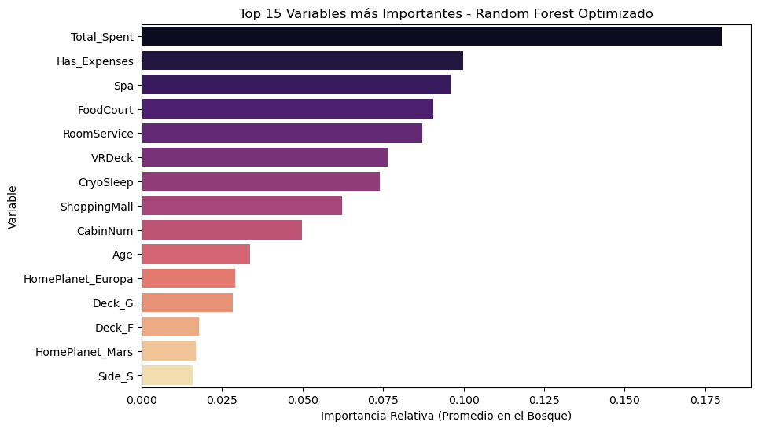

```
--- Análisis de Coherencia ---
El modelo estuvo altamente indeciso en 153 pasajeros del conjunto de prueba.
Estas son predicciones donde la probabilidad de ser transportado fue casi un 'volado' (50/50).
```

```python
# Escribe tu código aquí

import pandas as pd
import matplotlib.pyplot as plt
import seaborn as sns

# --- 1. Extracción de la Importancia de Variables ---
# El Random Forest ya calculó esto internamente durante el fit()
importancias_rf = mejor_modelo_rf.feature_importances_

df_importancia_rf = pd.DataFrame({
    'Variable': X.columns,
    'Importancia': importancias_rf
})

# Ordenamos de mayor a menor importancia
df_importancia_rf = df_importancia_rf.sort_values(by='Importancia', ascending=False)

# Filtramos variables que aportaron muy poco (opcional, para limpiar el gráfico)
df_top_importancia = df_importancia_rf.head(15)

# --- 2. Visualización (Feature Importance) ---
plt.figure(figsize=(10, 6))
# Usamos el mapa de color 'magma' para distinguirlo de los modelos previos
sns.barplot(x='Importancia', y='Variable', data=df_top_importancia, palette='magma')
plt.title('Top 15 Variables más Importantes - Random Forest Optimizado')
plt.xlabel('Importancia Relativa (Promedio en el Bosque)')
plt.ylabel('Variable')
plt.show()

# --- 3. Análisis de las predicciones dudosas (Opcional) ---
# Extraemos los casos donde el modelo estuvo muy indeciso (probabilidad entre 0.45 y 0.55)
df_errores = pd.DataFrame({
    'Clase_Real': y_test,
    'Prediccion': y_pred_test_rf,
    'Probabilidad': y_prob_test_rf
})
indecisos = df_errores[(df_errores['Probabilidad'] >= 0.45) & (df_errores['Probabilidad'] <= 0.55)]

print(f"\n--- Análisis de Coherencia ---")
print(f"El modelo estuvo altamente indeciso en {len(indecisos)} pasajeros del conjunto de prueba.")
print("Estas son predicciones donde la probabilidad de ser transportado fue casi un 'volado' (50/50).")
```